# Tuto 5 : forêts aléatoires et comparaison de méthodes

```r
library(tidyverse)
theme_set(theme_classic(base_size=12))
```

## Exercice 1

On considère les données **spam** du package **Kernlab**.

```r
library(kernlab)
data(spam)
```

1. Expliquer le graphe suivant.

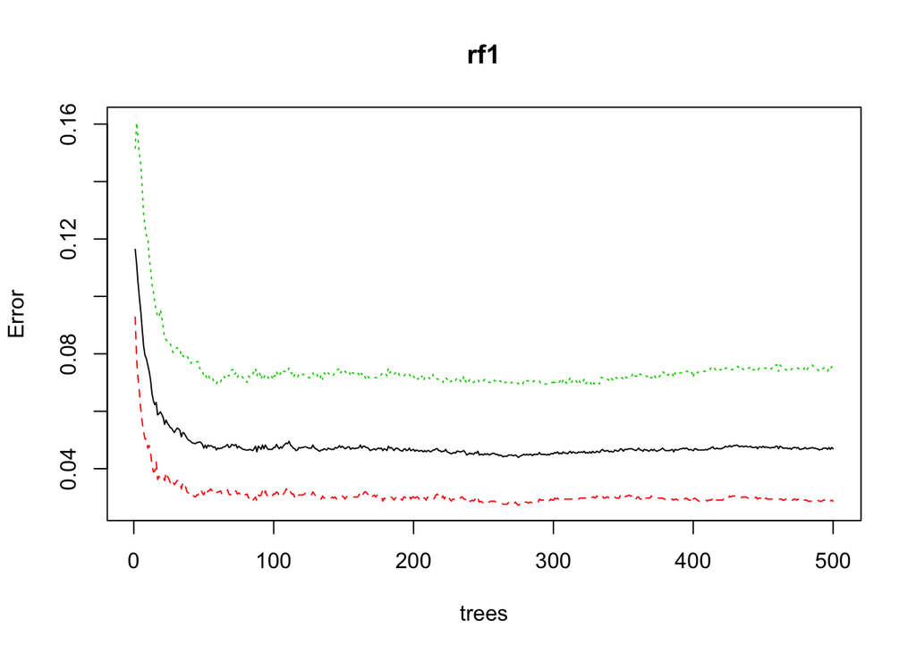

```r
library(randomForest)
rf1 <- randomForest(type~.,data=spam)
plot(rf1)
```

On visualise les erreurs (erreur de classification, 1-spécificité et 1- sensibilité) en fonction du nombre d’arbre. Cette sortie peut être utilisée pour vérifier si la forêt a bien convergé.

2. Construire une nouvelle forêt aléatoire avec **mtry=1** et comparer les 2 forêts.

```r
rf2 <- randomForest(type~.,data=spam,mtry=1)
rf1
```

```
##
## Call:
##  randomForest(formula = type ~ ., data = spam)
##                Type of random forest: classification
##                      Number of trees: 500
## No. of variables tried at each split: 7
##
##         OOB estimate of  error rate: 4.69%
## Confusion matrix:
##         nonspam spam class.error
## nonspam    2708   80  0.02869440
## spam        136 1677  0.07501379
```

```r
rf2
```

```
##
## Call:
##  randomForest(formula = type ~ ., data = spam, mtry = 1)
##                Type of random forest: classification
##                      Number of trees: 500
## No. of variables tried at each split: 1
##
##         OOB estimate of  error rate: 8.06%
## Confusion matrix:
##         nonspam spam class.error
## nonspam    2728   60   0.0215208
## spam        311 1502   0.1715389
```

L’erreur OOB est clairement plus importante avec **mtry=1**.

3. Séparer les données en un échantillon d’apprentissage de taille 3000 et un échantillon test de taille 1601.

```r
set.seed(1234)
perm <- sample(nrow(spam))
train <- spam %>% slice(perm[1:3000])
test <- spam %>% slice(-perm[1:3000])
```

4. Construire deux forêts aléatoires sur les données d’apprentissage : une avec les valeurs par défaut, l’autre avec **mtry=1**.

```r
rf1 <- randomForest(type~.,data=train)
rf2 <- randomForest(type~.,data=train,mtry=1)
```

5. Calculer les erreurs de classification des deux forêts en utilisant les données test.

```r
prev <- data.frame(rf1=predict(rf1,newdata=test,type="class"),rf2=predict(rf2,newdata=test,type="class"),Y=test$type)
prev %>% summarize_at(1:2,~mean(Y!=.))
```

| rf1 | rf2 |
| --- | --- |
| 0.05371643 | 0.08931918 |

6. Utiliser la fonction **train** du package **caret** pour choisir le paramètre **mtry** dans la grille **seq(1,30,by=5)**.

```r
library(caret)
grille.mtry <- data.frame(mtry=seq(1,30,by=5))
ctrl <- trainControl(method="oob")
library(doParallel) ## pour paralléliser
cl <- makePSOCKcluster(4)
registerDoParallel(cl)
set.seed(12345)
sel.mtry <- train(type~.,data=train,method="rf",trControl=ctrl,
tuneGrid=grille.mtry)
on.exit(stopCluster(cl))
sel.mtry
```

```
## Random Forest
##
## 3000 samples
##   57 predictor
##    2 classes: 'nonspam', 'spam'
##
## No pre-processing
## Resampling results across tuning parameters:
##
##   mtry  Accuracy   Kappa
##    1    0.9220000  0.8327504
##    6    0.9526667  0.9003416
##   11    0.9520000  0.8989075
##   16    0.9493333  0.8933555
##   21    0.9493333  0.8932590
##   26    0.9470000  0.8882591
##
## Accuracy was used to select the optimal model using the largest value.
## The final value used for the model was mtry = 6.
```

```r
sel.mtry$bestTune
```

|  | mtry |
| --- | --- |
| 2 | 6 |

On remarque que le paramètre choisi est proche de la valeur par défaut.

7. Construire un arbre sur les données d’apprentissage.

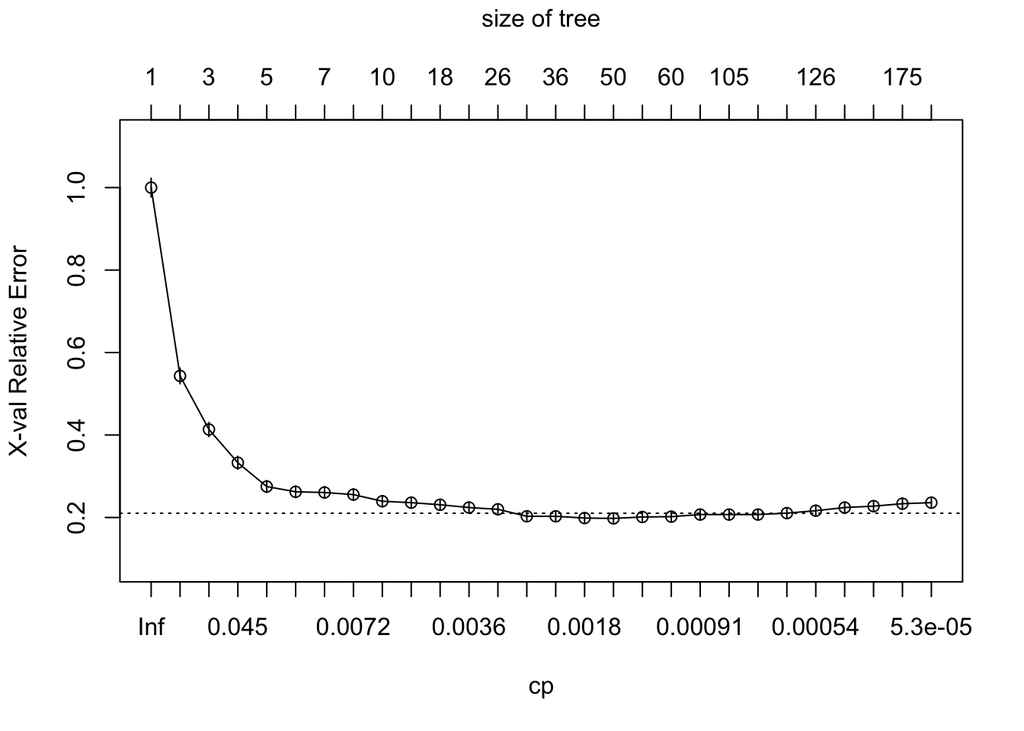

```r
library(rpart)
library(rpart.plot)
tree <- rpart(type~.,data=train,cp=0.00001,minsplit=3)
plotcp(tree)
```

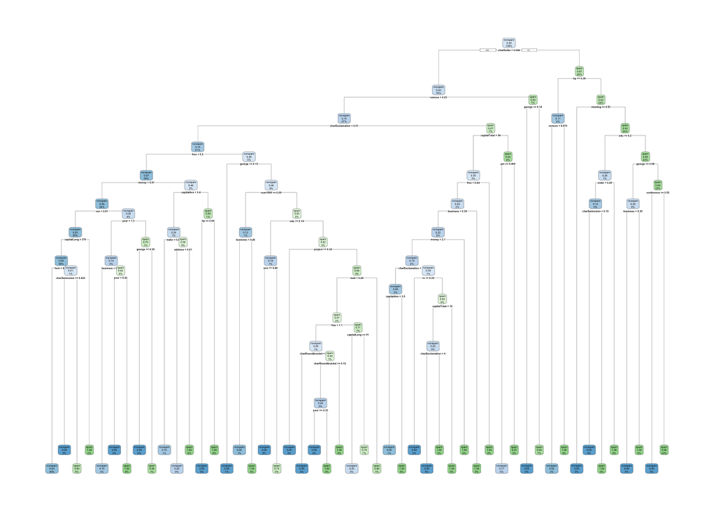

```r
cp_opt <- tree$cptable %>% as.data.frame() %>% filter(xerror==min(xerror)) %>% dplyr::select(CP) %>% slice(1) %>% as.numeric()
opt.tree <- prune(tree,cp=cp_opt)
rpart.plot(opt.tree)
```

8. Comparer les courbes ROC et les AUC des 2 forêts et de l’arbre (on utilisera l’échantillon test pour calculer les valeurs de score).

On peut tracer les courbes ROC avec

- la fonction **roc** du package *pROC* :

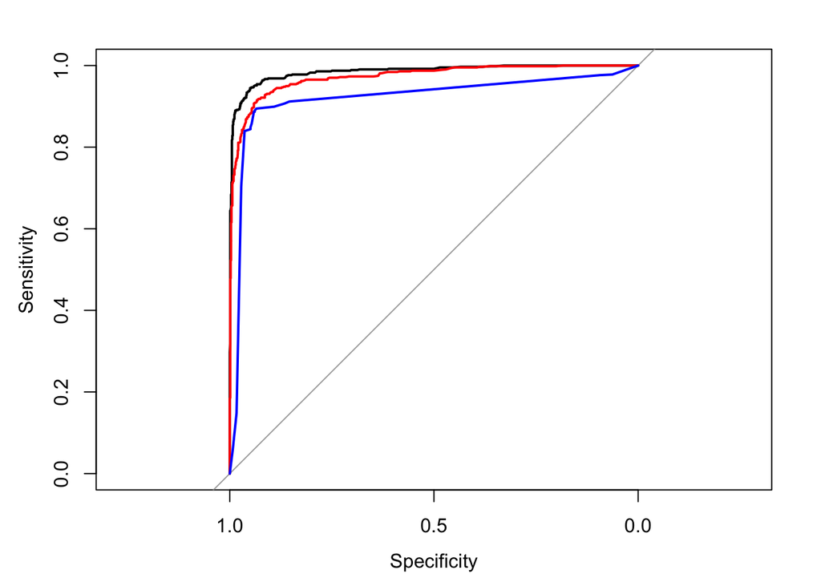

```r
library(pROC)
score1 <- predict(rf1,newdata=test,type="prob")[,2]
score2 <- predict(rf2,newdata=test,type="prob")[,2]
score3 <- predict(opt.tree,newdata=test,type="prob")[,2]
R1 <- roc(test$type,score1)
R2 <- roc(test$type,score2)
R3 <- roc(test$type,score3)
plot(R1)
plot(R2,add=TRUE,col="red")
plot(R3,add=TRUE,col="blue")
```

- avec le verbe **geom_roc** pour obtenir un graphe **ggplot** :

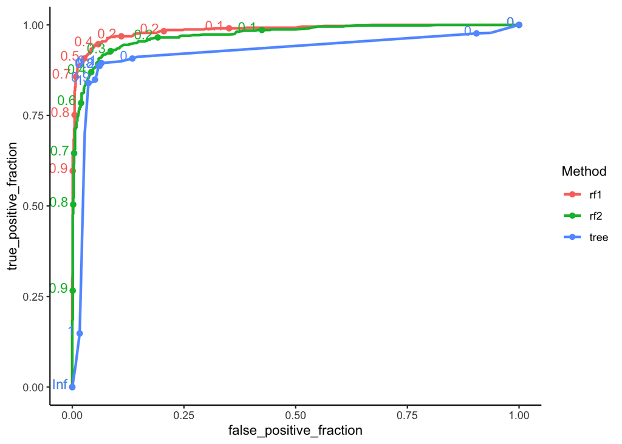

```r
library(plotROC)
score <- data.frame(rf1=score1,rf2=score2,tree=score3,obs=test$type) %>% gather(key="Method",value="score",-obs)

ggplot(score)+aes(d=obs,m=score,color=Method)+geom_roc()+theme_classic()
```

On obtient les AUC avec

```r
score %>% group_by(Method) %>%
  summarize(AUC=pROC::auc(obs,score)) %>%
  arrange(desc(AUC)) %>% mutate(AUC=round(AUC,3))
```

| Method | AUC |
| --- | --- |
| rf1 | 0.985 |
| rf2 | 0.972 |
| tree | 0.920 |

9. Calculer les erreurs de classification des 3 méthodes.

```r
score4 <- score %>%
  mutate(Prev=dplyr::recode(as.character(score>0.5),"TRUE"="spam","FALSE"="nonspam"))
score4 %>% group_by(Method) %>% summarise(Err=mean(obs!=Prev)) %>%
  arrange(Err) %>% mutate(Err=round(Err,3))
```

| Method | Err |
| --- | --- |
| rf1 | 0.054 |
| tree | 0.081 |
| rf2 | 0.089 |

10. Représenter les 10 variables les plus importantes de la meilleure forêt aléatoire à l’aide d’un diagramme en barres.

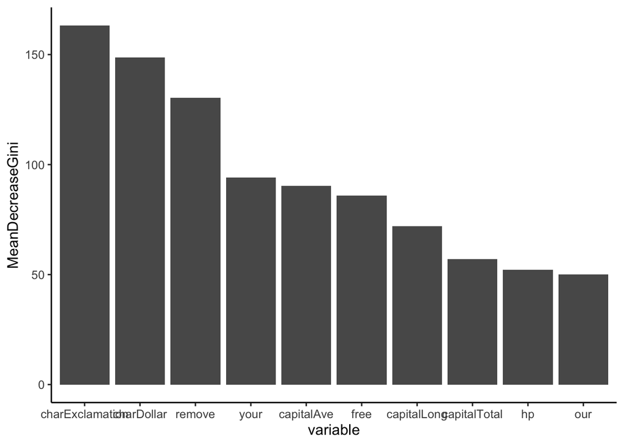

```r
imp <- randomForest::importance(rf1) %>% as.data.frame()
imp1 <- imp %>% mutate(variable=rownames(imp)) %>% as_tibble() %>% arrange(desc(MeanDecreaseGini)) %>% slice(1:10)
imp1$variable <- factor(as.character(imp1$variable),levels=imp1$variable)
ggplot(imp1)+aes(x=variable,y=MeanDecreaseGini)+geom_bar(stat = "identity")
```

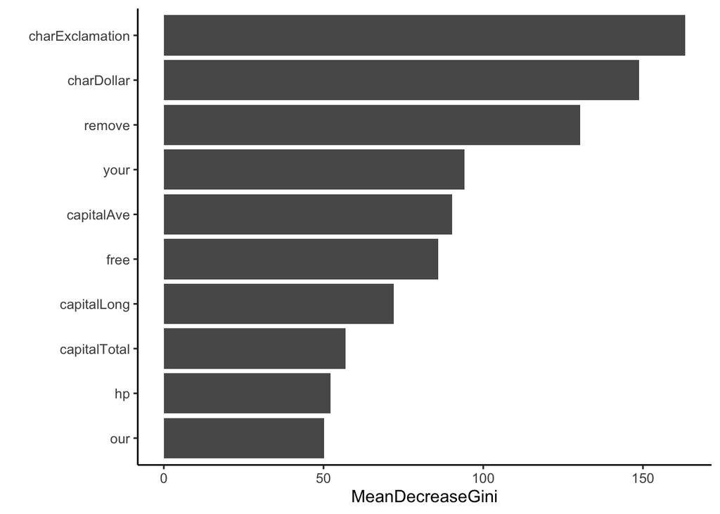

```r
ggplot(imp1) + aes(x=reorder(variable,MeanDecreaseGini),y=MeanDecreaseGini)+geom_bar(stat="identity")+coord_flip()+xlab("")
```

11. Comparer les temps de calcul de la fonction **ranger** du package **ranger** et de la fonction **randoForest** du package **randomForest**.

```r
library(ranger)
system.time(rf3 <- ranger(type~.,data=train))
```

```
##    user  system elapsed
##   1.239   0.008   0.392
```

```r
system.time(rf4 <- randomForest(type~.,data=train))
```

```
##    user  system elapsed
##   5.527   0.048   5.634
```

**ranger** est beaucoup plus efficace au niveau du temps de calcul. Cette fonction a été proposée pour améliorer les temps de calcul pour les données de grande dimension. On pourra trouver des informations [ici](https://arxiv.org/pdf/1508.04409.pdf).

## Exercice 2

On considère les données *internet advertisements* disponibles [ici](https://archive.ics.uci.edu/ml/datasets/internet+advertisements)).

1. Importer les données et expliquer le problème.

```r
ad_data <- read_csv("https://archive.ics.uci.edu/ml/machine-learning-databases/internet_ads/ad.data",col_names = FALSE,na=c("?"))
dim(ad_data)
```

```
## [1] 3279 1559
```

Ces données représentent la présence/absence d’images publicitaires sur des pages web. Les variables explicatives représentent la géométrie de l’image ainsi que la présence de phrases, d’indentation et de mots. Le problème est de prédire si une image est une publicité (“ad”) ou non (“nonad”). On dispose de 3279 observations and 1558 variables. Le problème peut ainsi être considéré comme un problème de grande dimension.

2. Nommer $Y$ la variable à expliquer et supprimer les observations qui contiennent des données manquantes.

```r
names(ad_data)[ncol(ad_data)] <- "Y"
ad_data$Y <- as.factor(ad_data$Y)

ind_na <- apply(is.na(ad_data),1,any)
ad_data1 <- ad_data[ind_na==F,]
#with dplyr
ad_data1 <- ad_data %>% filter(ind_na==F)

sum(is.na(ad_data1))
```

```
## [1] 0
```

```r
summary(ad_data1$Y)
```

```
##    ad. nonad.
##    381   1978
```

3. Calculer la variance des variables explicatives. Interpréter.

```r
ind <- apply(ad_data1[,-ncol(ad_data1)],2,var)!=0
ind <- c(ind,TRUE)
ind[is.na(ind)] <- TRUE
```

Certaines entrées ont une variance nulle, cela signifie que toutes les observations sont identiques. Nous supprimons ces variables.

```r
ad_data1 <- ad_data1[,ind]
```

4. Séparer les données en un échantillon d’apprentissage de taille 2000 et un échantillon test de taille 359.

```r
set.seed(1234)
ind_train <- sample(nrow(ad_data1),2000)
train <- ad_data1%>%slice(ind_train)
test <- ad_data1%>%slice(-ind_train)
```

4. Calculer la variance des variables explicatives. Interpréter.

```r
ind <- apply(train[,-ncol(train)],2,var)!=0
ind <- c(ind,TRUE)
ind[is.na(ind)] <- TRUE
train <- train[,ind]
test <- test[,ind]
```

Certaines entrées ont une variance nulle, cela signifie que toutes les observations sont identiques. Nous supprimons ces variables.

5. Construire un arbre, une lda et une forêt aléatoire sur les données d’apprentissage.
- Lda

```r
library(MASS)
mod.lda <- lda(Y~.,data=train)
```

- Arbre

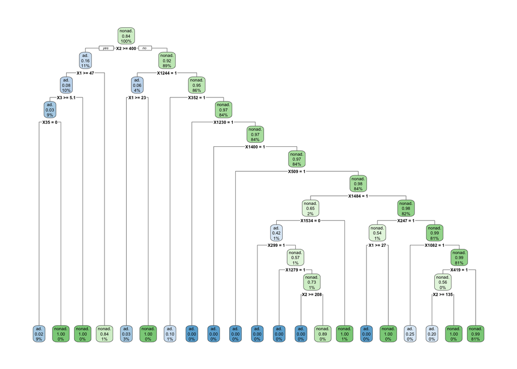

```r
tree1 <- rpart(Y~.,data=train,cp=0.000001,minsplit=2)
cp_opt <- tree1$cptable %>% as.data.frame() %>% filter(xerror==min(xerror)) %>% dplyr::select(CP) %>% slice(1) %>% as.numeric()
opt.tree <- prune(tree1,cp=cp_opt)
library(rpart.plot)
rpart.plot(opt.tree)
```

- Forêt aléatoire

**randomForest** peut prendre un peu de temps

```r
rf <- randomForest(Y~.,data=train)
prev_rf <- predict(rf,newdata=test)
mean(prev_rf!=test$Y)
```

On propose de plutot utiliser **ranger**.

```r
rf1 <- ranger(Y~.,data=train)
prev_rf1 <- predict(rf1,data=test)$predictions
mean(prev_rf1!=test$Y)
```

```
## [1] 0.03064067
```

6. Comparer les 3 méthodes avec la courbe ROC puis l’AUC.

```r
rf2 <- ranger(Y~.,data=train,probability=TRUE)
```

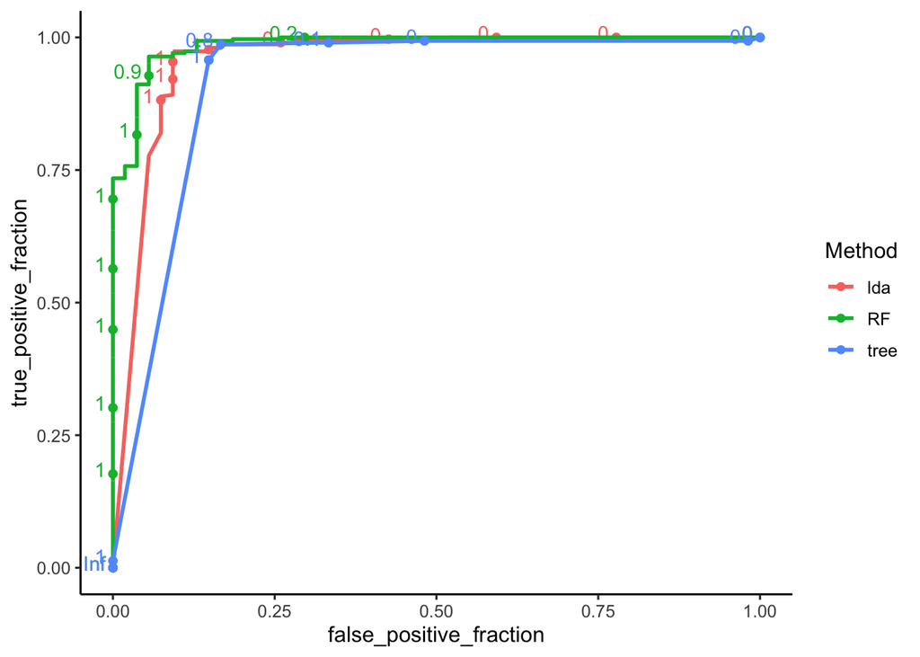

```r
score <- matrix(0,nrow=nrow(test),ncol=3)
score[,1] <- predict(mod.lda,newdata=test)$posterior[,2]
score[,2] <- predict(opt.tree,newdata=test,type="prob")[,2]
score[,3] <- predict(rf2,data=test)$predictions[,2]
score <- score %>% as.data.frame() %>% mutate(obs=test$Y)
colnames(score)[1:3] <- c("lda","tree","RF")
score2 <- score %>% gather(key="Method",value="Score",-obs)
rocplot <- ggplot(score2)+aes(m=Score,d=obs,color=Method)+geom_roc()
rocplot
```

```r
score2 %>% group_by(Method) %>% summarize(AUC=round(auc(obs,Score),3)) %>% arrange(desc(AUC))
```

| Method | AUC |
| --- | --- |
| RF | 0.986 |
| lda | 0.956 |
| tree | 0.917 |

7. Faire le même travail avec une validation croisée 10 blocs

```r
score.cv <- matrix(0,nrow=nrow(ad_data1),ncol=3) %>% as.data.frame()
names(score.cv) <- c("arbre","lda","foret")
K <- 10
set.seed(1234)
kfolds <- createFolds(1:nrow(ad_data1),k=K)
for (j in 1:K){
#  print(j)
  train <- ad_data1[-kfolds[[j]],]
  test <- ad_data1[kfolds[[j]],]
  ind <- apply(train[,-ncol(train)],2,var)!=0
  ind <- c(ind,TRUE)
  ind[is.na(ind)] <- TRUE
  train <- train[,ind]
  test <- test[,ind]
  tree <- rpart(Y~.,data=train,minsplit=2,cp=1e-9)
  cp_opt <- tree$cptable %>% as.data.frame() %>% filter(xerror==min(xerror)) %>% slice(1) %>% dplyr::select(CP) %>% as.numeric()
  opt <- prune(tree,cp=cp_opt)
  m.lda <- lda(Y~.,data=train)
  foret <- ranger(Y~.,data=train,probability=TRUE)
  score.cv[kfolds[[j]],1] <- predict(opt,newdata=test,type="prob")[,2]
  score.cv[kfolds[[j]],2] <- predict(m.lda,newdata=test)$posterior[,2]
  score.cv[kfolds[[j]],3] <- predict(foret,data=test)$predictions[,2]
}
```

On peut en déduire les courbes ROC et l’AUC

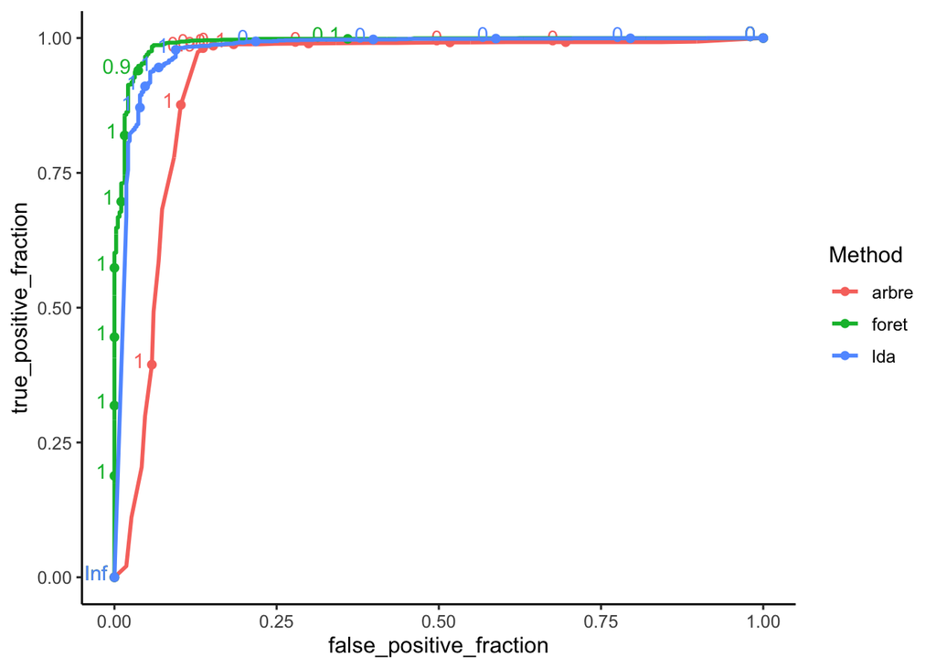

```r
score.cv <- score.cv %>% mutate(obs=ad_data1$Y)
score.cv2 <- score.cv %>% gather(key="Method",value="Score",-obs)
rocplot <- ggplot(score.cv2)+aes(m=Score,d=obs,color=Method)+geom_roc()
rocplot
```

```r
score.cv2 %>% group_by(Method) %>% summarize(AUC=round(auc(obs,Score),3)) %>% arrange(desc(AUC))
```

| Method | AUC |
| --- | --- |
| foret | 0.991 |
| lda | 0.978 |
| arbre | 0.927 |

Ainsi que les erreurs de classification.

```r
prev <- score.cv %>% mutate_at(1:3,round) %>% mutate(obs=ad_data1$Y,obs=recode_factor(obs,ad.="0",nonad.="1"))
prev %>% summarise_at(1:3,~mean(obs!=.))
```

| arbre | lda | foret |
| --- | --- | --- |
| 0.03645613 | 0.03560831 | 0.02289106 |